# DTI class imbalances

Let’s see if anything gets better if we address some of the class imbalances.

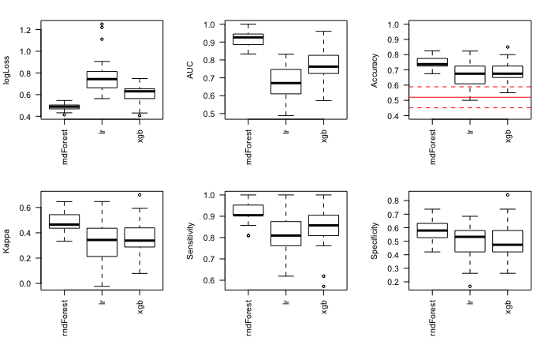

```r
source('~/ncr_notebooks/baseline_prediction/src/aux_functions.R')
root_fname = '~/data/baseline_prediction/results/stripped_allDTI_NVvsADHD_big'
do_metrics_plots(root_fname)
```

```r
tract_data = read.csv('~/data/baseline_prediction/stripped/dti.csv')
rm_me = (tract_data$fa_avg < .4 | tract_data$ad_avg < 1.18 | tract_data$rd_avg > .65 | tract_data$rd_avg < .5 |
         tract_data$norm.trans > .45 | tract_data$norm.rot > .008 | tract_data$goodSlices < 45 | tract_data$goodSlices > 70)
print(sprintf('Reducing from %d to %d scans', nrow(tract_data), nrow(tract_data)-sum(rm_me)))
```

```
[1] "Reducing from 727 to 656 scans"
```

```r
tract_data = tract_data[!rm_me, ]
gf_fname = '~/data/baseline_prediction/stripped/clinical.csv'
gf = read.csv(gf_fname)
gf = gf[gf$BASELINE=='BASELINE', ]
my_ids = intersect(gf$MRN, tract_data$MRN)
merged = mergeOnClosestDate(gf, tract_data, my_ids)
rm_me = abs(merged$dateX.minus.dateY.months) > 12
print(sprintf('Reducing from %d to %d scans', nrow(merged), nrow(merged)-sum(rm_me)))
```

```
[1] "Reducing from 289 to 200 scans"
```

```r
merged = merged[!rm_me, ]
```

The GAS distribution looks like this:

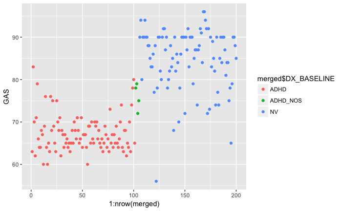

```r
library(ggplot2)
ggplot(merged) + geom_point(aes(1:nrow(merged), GAS, color=merged$DX_BASELINE))
```

Wendy has already looked over those outliers, so let’s just go ahead and split them based on GAS:

```r
myc = kmeans(merged[merged$DX_BASELINE != 'NV',]$GAS, 2)
print(sprintf('Cutoff: %.2f', myc$centers[1] + diff(myc$centers)/2))
```

```
[1] "Cutoff: 68.91"
```

```r
library(caret)
library(randomForest)
seed = 107
phen_vars = c(which(grepl("^FA_", colnames(merged))),
              which(grepl("^AD_", colnames(merged))),
              which(grepl("^RD_", colnames(merged))),
              which(grepl("^MO_", colnames(merged)))
              )
X = merged[, phen_vars]
y = as.character(merged$DX_BASELINE)
y[y != 'NV'] = 'ADHD'
y[y == 'ADHD' & merged$GAS > 68.91] = 'ADHD_high'
y[y == 'ADHD'] = 'ADHD_low'
y = factor(y, levels=c('NV', 'ADHD_low', 'ADHD_high'))
# remove subjects with NA
rm_me = rowSums(is.na(X)) > 0
X = X[!rm_me, ]
y = y[!rm_me]
```

Let’s do some ML now:

```r
set.seed(seed)
splitIndex <- createDataPartition(y, p = .50,
                                  list = FALSE,
                                  times = 1)
Xtrain <- X[ splitIndex,]
Xtest <- X[-splitIndex,]
ytrain <- y[ splitIndex]
ytest <- y[-splitIndex]

prop.table(table(ytrain))
```

```
ytrain
       NV  ADHD_low ADHD_high
     0.48      0.36      0.16
```

```r
ctrl <- trainControl(method = "cv", number = 5)
tbmodel <- train(Xtrain, ytrain, method = "treebag",
                 trControl = ctrl)
predictors <- colnames(Xtrain)
pred <- predict(tbmodel, Xtest)
```

```r
library(pROC)
auc <- multiclass.roc(as.numeric(ytest), as.numeric(pred))
print(auc)
```

```
Call:
multiclass.roc.default(response = as.numeric(ytest), predictor = as.numeric(pred))

Data: as.numeric(pred) with 3 levels of as.numeric(ytest): 1, 2, 3.
Multi-class area under the curve: 0.5224
```

Just a quick check of whether a tree bag model might perform better in the binary classification, even though there is no class imbalance here:

```r
phen_vars = c(which(grepl("^FA_", colnames(merged))),
              which(grepl("^AD_", colnames(merged))),
              which(grepl("^RD_", colnames(merged))),
              which(grepl("^MO_", colnames(merged)))
              )
X = merged[, phen_vars]
y = as.character(merged$DX_BASELINE)
y[y != 'NV'] = 'ADHD'
y = factor(y, levels=c('NV', 'ADHD'))
set.seed(seed)
splitIndex <- createDataPartition(y, p = .80,
                                  list = FALSE,
                                  times = 1)
Xtrain <- X[ splitIndex,]
Xtest <- X[-splitIndex,]
ytrain <- y[ splitIndex]
ytest <- y[-splitIndex]

prop.table(table(ytrain))
```

```
ytrain
   NV  ADHD
0.475 0.525
```

```r
ctrl <- trainControl(method = "cv", number = 5)
tbmodel <- train(Xtrain, ytrain, method = "treebag",
                 trControl = ctrl)
predictors <- colnames(Xtrain)
pred <- predict(tbmodel, Xtest)
```

```r
auc <- roc(as.numeric(ytest), as.numeric(pred))
print(auc)
```

```
Call:
roc.default(response = as.numeric(ytest), predictor = as.numeric(pred))

Data: as.numeric(pred) in 19 controls (as.numeric(ytest) 1) < 21 cases (as.numeric(ytest) 2).
Area under the curve: 0.5677
```

Not really… quite poor actually. The issue with symptom counts is also how badly distributed it is when we include NVs:

```r
par(mfrow=c(1, 3))
plot(merged$SX_inatt)
plot(merged$SX_HI)
```

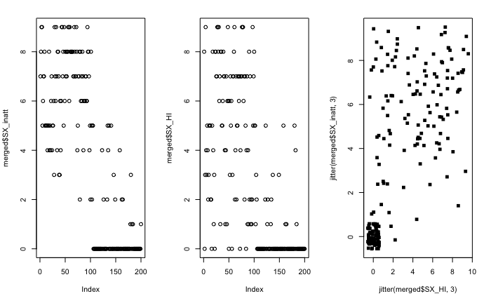

```r
plot(jitter(merged$SX_inatt, 3) ~ jitter(merged$SX_HI, 3), pch = 15)
```

```r
table(merged$SX_inatt)
```

```
 0  1  2  3  4  5  6  7  8  9
78  4  8  5 12 20 15 21 24 13
```

```r
table(merged$SX_HI)
```

```
 0  1  2  3  4  5  6  7  8  9
88 14 13  9 10 17  8 20 11 10
```

Could I predict a squeakky clean person against the others? Maybe we could use that as some sort of baseline detection, and go for symptoms that way. Maybe even incorporate GAS in that classification? Let’s see if this classification does better in plotting GAS:

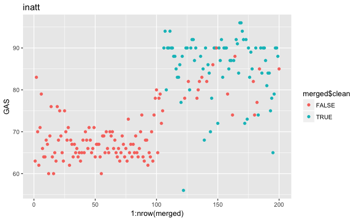

```r
merged$clean = merged$SX_inatt == 0
ggplot(merged) + geom_point(aes(1:nrow(merged), GAS, color=merged$clean)) + ggtitle('inatt')
```

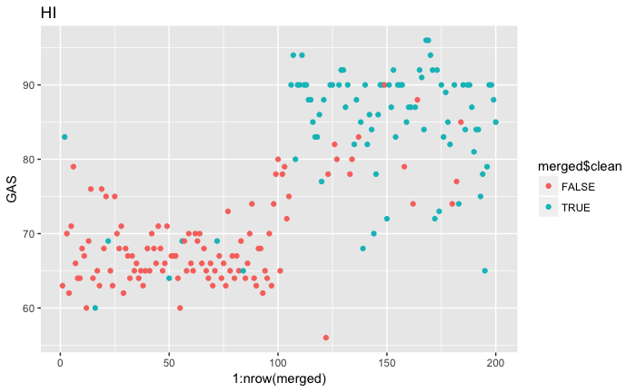

```r
merged$clean = merged$SX_HI == 0
ggplot(merged) + geom_point(aes(1:nrow(merged), GAS, color=merged$clean)) + ggtitle('HI')
```

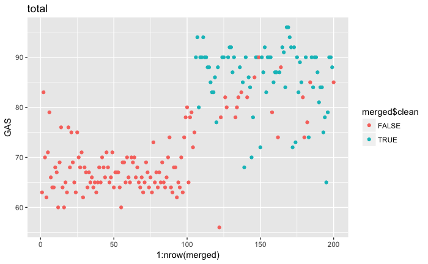

```r
merged$clean = merged$SX_inatt == 0 & merged$SX_HI == 0
ggplot(merged) + geom_point(aes(1:nrow(merged), GAS, color=merged$clean)) + ggtitle('total')
```

Not sure how much GAS would help… of course, not all NVs are clean. LEt’s try to play with this without GAS first, and see what we get.

```r
myseed = 107
phen_vars = c(which(grepl("^FA_", colnames(merged))),
              which(grepl("^AD_", colnames(merged))),
              which(grepl("^RD_", colnames(merged))),
              which(grepl("^MO_", colnames(merged)))
              )
X = merged[, phen_vars]
y = as.character(merged$DX_BASELINE)
y[merged$SX_inatt <= 0 & merged$SX_HI <= 0] = 'clean'
y[y != 'clean'] = 'dirty'
y = factor(y, levels=c('clean', 'dirty'))
# remove subjects with NA
rm_me = rowSums(is.na(X)) > 0
X = X[!rm_me, ]
y = y[!rm_me]
cpuDiff = 1
tuneLength = 10
default_preproc = c("center", 'scale')
set.seed(myseed)
split <- createDataPartition(y, p = .8, list = FALSE)
Xtrain <- X[ split, ]
ytrain <- y[ split ]
Xtest  <- X[-split, ]
ytest = y[-split]
set.seed(myseed)
index <- createMultiFolds(ytrain, times = 5)
library(doMC)
ncpus <- detectBatchCPUs()
njobs <- ncpus - cpuDiff
registerDoMC(njobs)
selFunc = 'oneSE'  # maybe try oneSE and tolerance as well?
# set.seed(myseed)
# rfFull <- train(Xtrain, ytrain,
#                 method = "rf",
#                 metric='ROC',
#                 # tuneLength = tuneLength,
#                 # ntree = 1000,
#                 trControl = fullCtrl,
#                 preProcess = default_preproc,
#                 tuneGrid=expand.grid(.mtry=c(1:sqrt(ncol(Xtrain)))))
    set.seed(myseed)
  if (length(levels(y)) > 2) {
    my_func = multiClassSummary
    if (metric == 'ROC') {
      metric = 'Mean_ROC'
    }
  } else {
    my_func = twoClassSummary
  }
  ctrl_cv <- trainControl(method = "repeatedcv",
                          number = 4,
                          repeats = 5,
                          classProbs = TRUE,
                          returnData = FALSE,
                          summaryFunction = my_func,
                          search='grid')
  fullCtrl <- trainControl(method = "repeatedcv",
                         repeats = 5,
                         index = index,
                         search='grid',
                         summaryFunction = twoClassSummary,
                         classProbs = TRUE)
  rndForestGrid <- expand.grid(.mtry=c(1:sqrt(ncol(Xtrain))))
      rfFull <- train(Xtrain, ytrain,
                            method = "rf",
                            trControl = fullCtrl,
                            tuneGrid=rndForestGrid,
                            metric = 'ROC',
                            preProcess = default_preproc)

rfFull
```

```
Random Forest

159 samples
 44 predictor
  2 classes: 'clean', 'dirty'

Pre-processing: centered (44), scaled (44)
Resampling: Cross-Validated (10 fold, repeated 5 times)
Summary of sample sizes: 144, 143, 143, 143, 143, 143, ...
Resampling results across tuning parameters:

  mtry  ROC        Sens       Spec
  1     0.6513571  0.2490476  0.8546667
  2     0.6485635  0.2880952  0.8502222
  3     0.6382540  0.2952381  0.8322222
  4     0.6387169  0.3009524  0.8180000
  5     0.6329735  0.3014286  0.8240000
  6     0.6350582  0.3152381  0.8244444

ROC was used to select the optimal model using  the largest value.
The final value used for the model was mtry = 1.
```

```r
pred = predict(rfFull, Xtest)
postResample(pred, ytest)
```

```
   Accuracy       Kappa
 0.56410256 -0.06763285
```

```r
roc(as.numeric(ytest), as.numeric(pred))
```

```
Call:
roc.default(response = as.numeric(ytest), predictor = as.numeric(pred))

Data: as.numeric(pred) in 15 controls (as.numeric(ytest) 1) < 24 cases (as.numeric(ytest) 2).
Area under the curve: 0.4708
```

```r
varSeq = 1:ncol(X)
ctrl <- rfeControl(method = "repeatedcv", repeats = 5,
                   saveDetails = TRUE,
                   index = index,
                   returnResamp = "final")
ctrl$functions <- rfFuncs
set.seed(myseed)
rfRFE <- rfe(Xtrain, ytrain,
             sizes = varSeq,
             rfeControl = ctrl)
rfRFE
```

```
Recursive feature selection

Outer resampling method: Cross-Validated (10 fold, repeated 5 times)

Resampling performance over subset size:

 Variables Accuracy    Kappa AccuracySD KappaSD Selected
         1   0.5069 -0.05057    0.11303  0.2382
         2   0.5640  0.05336    0.11917  0.2557
         3   0.5791  0.07660    0.10983  0.2326
         4   0.5860  0.09631    0.12038  0.2460
         5   0.5897  0.10650    0.10990  0.2223
         6   0.6122  0.14654    0.10835  0.2303
         7   0.6183  0.15467    0.10818  0.2246
         8   0.6132  0.13555    0.09592  0.2007
```

[output cut: 39 more lines]

```r
cvCtrl <- trainControl(method = "cv",
                       verboseIter = FALSE,
                       allowParallel = FALSE)
ctrl$functions <- caretFuncs
set.seed(myseed)
svmRRFE <- rfe(Xtrain, ytrain,
              sizes = varSeq,
              rfeControl = ctrl,
              method = "svmRadial",
              tuneLength = tuneLength,
              preProc = default_preproc,
              trControl = cvCtrl)
```

```r
ldata = X
groups = y
root_fname = '~/data/baseline_prediction/results/TMP'
save(ldata, groups, file=sprintf('%s.RData', root_fname), compress=T)
runInCluster(root_fname, train_test_ratio=.7, cpuDiff=1, nsplits=1, nrepeatcv=5, run_models=c('rndForest', 'lr'))
```

```
[1] 7
```

```
[1] 7

Working on split 1 of 1
Running random forests
   user  system elapsed
 65.169   2.848  10.080

Running logistic regression
   user  system elapsed
 13.474   1.497   2.639
```

```r
do_metrics_plots(root_fname)
```

[output not shown]